# Practice 4: Advanced Tabular Data Manipulation

This demonstration combines information from multiple tables using the `dplyr` package to gain insight into patient health records.

#### Instructions

This notebook includes a framework for inspecting data in the example healthcare data set. Skeleton code for the analysis is provided for you. Your job is to fill in missing code denoted by ellipses (`...`) in the notebook. Each ellipse includes a commented `TODO` statement above it with instructions. Please fill in the missing code in the notebook.

#### Scope

This notebook includes material covered in Lecture 4: Advanced Tabular Data Manipulation. You will practice the following…

1. Identify and impute missing values
2. Pivot a table
3. Join multiple tables
4. Draw information from multiple tables to complete desired tasks

#### Data Description

> Jason Walonoski, Mark Kramer, Joseph Nichols, Andre Quina, Chris Moesel, Dylan Hall, Carlton Duffett, Kudakwashe Dube, Thomas Gallagher, Scott McLachlan, Synthea: An approach, method, and software mechanism for generating synthetic patients and the synthetic electronic health care record, Journal of the American Medical Informatics Association, Volume 25, Issue 3, March 2018, Pages 230–238, https://doi.org/10.1093/jamia/ocx079

The data may be downloaded by clicking [this](https://synthetichealth.github.io/synthea-sample-data/downloads/synthea_sample_data_csv_apr2020.zip) hyperlink. **Please ensure that all tables are stored subdirectory called “data” placed immediately inside the directory containing this notebook.**

#### Import Modules

```r
library(tidyverse)
```

#### Specify and Load Data

This demonstration will make use of data in the `data/patients.csv` and `data/medications.csv` files. Please use the `read.csv` function to load each table into its own data frame.

```r
# TODO: Specify the path to the `patients` table
path_patient <- "data/patients.csv"

# TODO: Load the patients table using the `read.csv` function
df_patient <- read.csv(path_patient)

# TODO: Specify the path to the `medications` table
path_medication <- "data/medications.csv"

# TODO: Load the medications table using the `read.csv` function
df_medication <- read.csv(path_medication)
```

#### Load Column Names

We’ve worked with the `data/patients.csv` table during previous examples, but we have not worked with the `data/medications.csv` table. Let’s extract the column names of `df_medications` to gain some insight into what data is represented.

```r
# Load the column names in `df_medication`
cols_medication <- colnames(df_medication)

# Print the column names
print(cols_medication)
```

```
##  [1] "START"             "STOP"
##  [3] "PATIENT"           "PAYER"
##  [5] "ENCOUNTER"         "CODE"
##  [7] "DESCRIPTION"       "BASE_COST"
##  [9] "PAYER_COVERAGE"    "DISPENSES"
## [11] "TOTALCOST"         "REASONCODE"
## [13] "REASONDESCRIPTION"
```

Notice, the medications table includes start and stop time points, encounter identifiers, payment information, and reasons for the medication.

#### Inspect the Distribution of Medication Counts by Patient

We will use information from the `medications` and `patients` tables to generate a distribution of medication counts per unique patient. We will begin working with the `medications` table, with which we will group rows by the `PATIENT` column, taking the size of each grouping. For this analysis, we will focus on the number of unique medications taken by each patient; even if the same medication is taken more than once, that medication will be counted only once.

```r
# To identify the number of medications taken by each patient, we only need the `PATENT` and `CODE` columns of the `medications` table
# For convenience, let's store those columns in their own data frame
med_patient_codes <- df_medication %>%
  select(PATIENT, CODE)

# Remove duplicate records with same values in `PATIENT` and `CODE` columns
med_patient_codes <- med_patient_codes %>%
  distinct()

# TODO: Group the medications table by the `PATIENT` column, and take the size of each group
# This will return the number of distinct medications that each patient is taking
med_patient_codes_grouped <- med_patient_codes %>%
  group_by(PATIENT) %>%
  summarise("med_count" = n()) %>%
  ungroup()
```

Keep in mind, patients with zero medications will not appear in the `med_patient_codes_grouped` table. Recall that the `df_patient` table includes all patients. We can use the `df_patient` table to fill in missing patient identifiers in the `med_patient_codes_grouped` table. Below, we select the patient identifiers from the `Id` column of the `df_patient` table and merge them with the `med_patient_codes_grouped` table to create a row for all patients.

```r
# Isolate the `Id` column of the `df_patient` table, and merge the column with the `med_patient_codes_grouped` table.
med_counts <- df_patient %>%
  select(Id) %>%
  merge(med_patient_codes_grouped, by.x = "Id", by.y = "PATIENT", all = TRUE)

# Print the result of the merged table
print(med_counts)
```

```
##                                        Id med_count
## 1    00185faa-2760-4218-9bf5-db301acf8274         4
## 2    0042862c-9889-4a2e-b782-fac1e540ecb4         3
## 3    0047123f-12e7-486c-82df-53b3a450e365         2
## 4    010d4a3a-2316-45ed-ae15-16f01c611674         1
## 5    01207ecd-9dff-4754-8887-4652eda231e2        NA
## 6    0149d553-f571-4e99-867e-fcb9625d07c2         6
## 7    01e1f394-7219-4189-bceb-3cbd90cff90b        10
## 8    023a7d29-32b3-4db5-89c8-b88bd7582ec0         5
## 9    0288abb6-633c-40c3-ba0c-66c7d957727e         5
## 10   02ea2f1a-ddcf-4809-8279-dde7a62e0318         3
## 11   02f9aadd-72de-4b20-b381-f4c3b1cf7aa3         4
## 12   03172f6e-fb21-4770-8eef-513730174ab7         7
## 13   0325261f-61eb-46f8-acc6-89d15053fecd        13
## 14   034e9e3b-2def-4559-bb2a-7850888ae060         1
```

[output cut: 1157 more lines]

You may notice that some rows have a missing value (`NA`) in the `med_count` column. These rows correspond to patients without medications, who do not appear in the `med_patient_codes_grouped` table. When we merged the `df_patient` and `med_patient_codes_grouped` tables, the `med_count` was not available for these rows. We will replace the missing values with zero.

```r
# Replace missing values with zero in the `med_count` column of the `med_counts` table
med_counts <- med_counts %>%
  mutate(med_count = replace_na(med_count, 0))
```

Finally, we can plot the medication counts from all patients using a histogram.

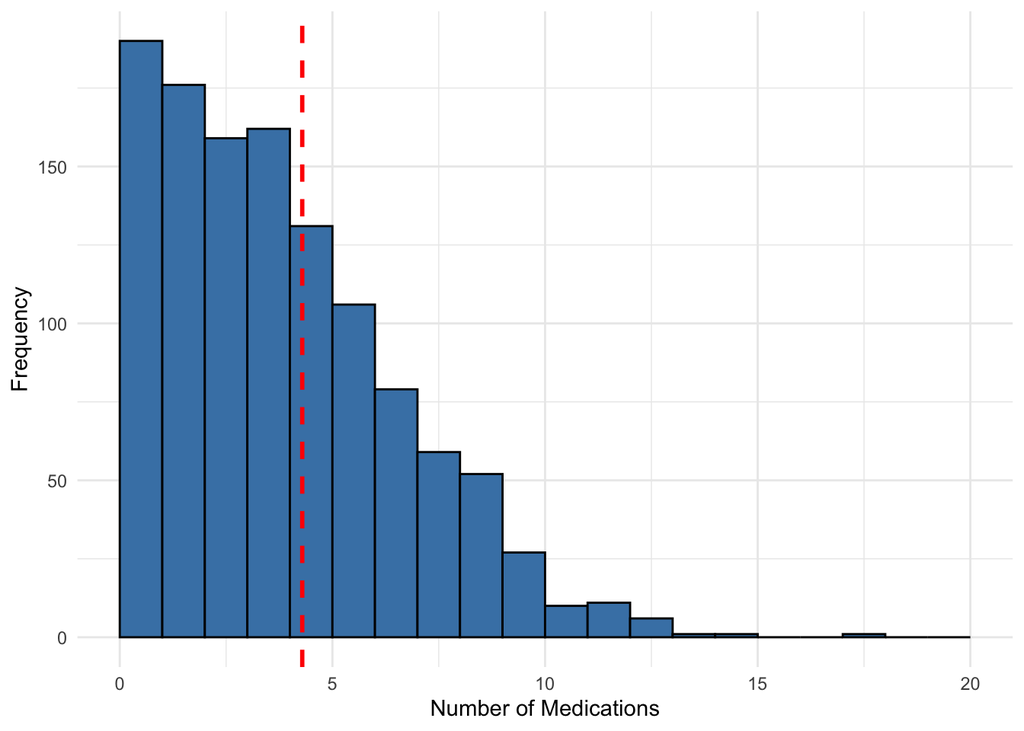

```r
# Specify appropriate bin edges for the histogram
bin_edges <- seq(0, 20, by = 1)

# Plot a histogram giving the medication counts
ggplot(med_counts, aes(x = med_count)) +
  geom_histogram(breaks = bin_edges, fill = "steelblue", color = "black") +
  labs(x = "Number of Medications", y = "Frequency") +
  geom_vline(aes(xintercept = mean(med_count)), color = "red", linetype = "dashed", size = 1) +
  xlim(0, 20) +
  theme_minimal()
```

#### Pivot the Medication Table

Assume we are interested in knowing which patients are taking a particular medication. We could filter the medications table on the `CODE` column to isolate records where the code matches the medication of interest. For practice, filter the `df_medication` table to rows where the `CODE` is `389221`.

```r
# TODO: Filter the `df_medication` table to rows where `CODE` is 389221
taking_med_389221 <- df_medication %>%
  filter(CODE == 389221)

# TODO: Identify the number of distinct patients taking medication 389221
# Hint: Start by isolating the `PATIENT` column, then filter to distinct patient identifiers and count the number of rows remaining
n_taking_med_389221 <- taking_med_389221 %>%
  select(PATIENT) %>%
  distinct() %>%
  nrow()

# Print the number of patients taking medicine 389221
print(paste(n_taking_med_389221, "patients are taking medication 389221."))
```

```
## [1] "69 patients are taking medication 389221."
```

Alternatively, we could pivot the `df_medications` table so that each column corresponds to a medication `CODE` and each row corresponds to a different patient. In this table, use a value of `1` to indicate that the patient corresponding to the row takes the medication corresponding to the column. Use a value of `0` to indicate that the patient corresponding to the row does not take the medication corresponding to the column.

```r
# TODO: Pivot the 'df_medication' table so that rows correspond to patients and columns correspond to codes
medications_pivot <- df_medication %>%
  select(PATIENT, CODE) %>%
  distinct() %>%
  mutate(value = 1) %>%
  pivot_wider(names_from = CODE, values_from = value, values_fill = 0)

# Display the pivoted medications table
print(medications_pivot)
```

```
## # A tibble: 1,107 x 132
##    PATIENT     `389221` `748856` `313782` `562251` `1534809`
##    <chr>          <dbl>    <dbl>    <dbl>    <dbl>     <dbl>
##  1 8d4c4326-e…        1        1        0        0         1
##  2 10339b10-3…        0        0        1        0         0
##  3 1d604da9-9…        0        0        0        1         0
##  4 f5dcd418-0…        0        0        1        0         0
##  5 034e9e3b-2…        0        0        1        0         0
##  6 72c0b9ce-7…        0        0        0        0         0
##  7 b1e9b0b9-d…        0        0        1        0         0
##  8 b58731cc-2…        0        1        0        0         1
##  9 cfee79fc-d…        0        0        0        0         0
## 10 ad2e9916-4…        0        0        0        0         0
## # … with 1,097 more rows, and 126 more variables:
## #   978950 <dbl>, 1000126 <dbl>, 849574 <dbl>,
## #   313820 <dbl>, 749762 <dbl>, 748879 <dbl>, 198405 <dbl>,
## #   308182 <dbl>, 311989 <dbl>, 1094107 <dbl>,
## #   310965 <dbl>, 856987 <dbl>, 1043400 <dbl>,
## #   834102 <dbl>, 746030 <dbl>, 751905 <dbl>,
## #   1367439 <dbl>, 748962 <dbl>, 1049630 <dbl>,
## #   310325 <dbl>, 309097 <dbl>, 831533 <dbl>, 310798 <dbl>,
## #   855332 <dbl>, 897718 <dbl>, 197604 <dbl>, 999967 <dbl>,
## #   997488 <dbl>, 1870230 <dbl>, 834061 <dbl>,
## #   895994 <dbl>, 2123111 <dbl>, 1790099 <dbl>,
## #   198240 <dbl>, 1605257 <dbl>, 429503 <dbl>,
## #   807283 <dbl>, 665078 <dbl>, 312617 <dbl>, 314231 <dbl>,
## #   749785 <dbl>, 309362 <dbl>, 312961 <dbl>, 197361 <dbl>,
## #   705129 <dbl>, 757594 <dbl>, 1804799 <dbl>,
## #   141918 <dbl>, 243670 <dbl>, 106258 <dbl>, 857005 <dbl>,
## #   1014676 <dbl>, 860975 <dbl>, 1660014 <dbl>,
## #   834357 <dbl>, 1190795 <dbl>, 1860154 <dbl>,
## #   1049221 <dbl>, 904419 <dbl>, 2001499 <dbl>,
## #   966222 <dbl>, 197591 <dbl>, 308971 <dbl>, 477045 <dbl>,
## #   861467 <dbl>, 833036 <dbl>, 235389 <dbl>, 749882 <dbl>,
## #   1732186 <dbl>, 1734919 <dbl>, 1601380 <dbl>,
## #   106892 <dbl>, 1860480 <dbl>, 752899 <dbl>,
## #   896209 <dbl>, 309043 <dbl>, 583214 <dbl>, 311995 <dbl>,
## #   308192 <dbl>, 1359133 <dbl>, 1856546 <dbl>,
## #   310436 <dbl>, 1599803 <dbl>, 1803932 <dbl>,
## #   1736776 <dbl>, 1736854 <dbl>, 866414 <dbl>,
## #   313988 <dbl>, 1719286 <dbl>, 197378 <dbl>,
## #   997501 <dbl>, 204892 <dbl>, 311372 <dbl>, 198031 <dbl>,
## #   198014 <dbl>, 197319 <dbl>, 789980 <dbl>, 105078 <dbl>,
## #   996740 <dbl>, 608139 <dbl>, …
```

Now, you can identify the number of patients taking each medication by taking sums down the columns.

```r
# Take a sum down the column of the pivot table to identify the number of patients taking each medication
# This will yield a named vector
n_taking_each_med <- colSums(medications_pivot[, -1])

# Convert the named vector into a data frame
n_taking_each_med <- data.frame(medication = names(n_taking_each_med), n_patients = n_taking_each_med)

# Identify the number of patients taking medication 389221
n_taking_med_389221_from_pivot <- n_taking_each_med %>%
  filter(medication == "389221") %>%
  select(n_patients)

# Print the number of patients taking medicine 389221
print(paste(n_taking_med_389221_from_pivot, "patients are taking medication 389221."))
```

```
## [1] "69 patients are taking medication 389221."
```

Sort the medication codes by the number of patients taking them. Then, plot a bar chart indicating the number of patients taking each of the top 10 most common medications.

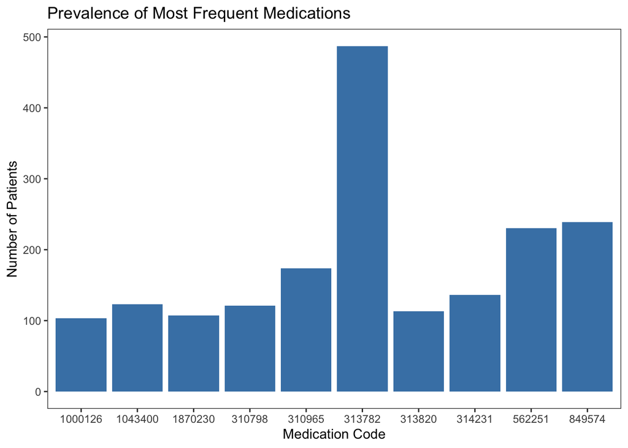

```r
# TODO: Sort the medication codes by the number of patients taking them
# Hint: Use the `arrange` function on the `n_taking_each_med` table
n_taking_each_med_sorted <- n_taking_each_med %>%
  arrange(desc(n_patients))

# TODO: Isolate the top 10 rows in `n_taking_each_med_sorted`
n_taking_top_10_meds <- n_taking_each_med_sorted %>%
  filter(row_number() <= 10)

# TODO: Generate a bar chart indicating the number of patients taking each of the top 10 most common medications
ggplot(n_taking_top_10_meds, aes(x = medication, y = n_patients)) +
  geom_bar(stat = "identity", fill = "steelblue") +
  labs(x = "Medication Code", y = "Number of Patients",
       title = "Prevalence of Most Frequent Medications") +
  theme(axis.text.x = element_text(angle = 45, hjust = 1)) +
  theme_bw() +
  theme(panel.grid.major = element_blank(),
        panel.grid.minor = element_blank())
```

#### Identify Minors Taking Many Medications

Our task is to identify patients under 18 years old who are taking “many” medications. We will define “many” medications as eight or more medications. This task could be used to identify eligible patients for a clinical trial using existing medical records. We will break the task down into four steps.

**STEP 1.** Using the `BIRTHDATE` column of the `df_patient` table, identify the age of each patient (in years) on a provided reference date. For help, review the `p3_basic_tabular_manipulation` notebook.

```r
# Age will be evaluated at January 1, 2023
ref_date <- as.Date("2023-01-01")

# Convert the `BIRTHDATE` column in the `df_patient` table to date format
df_patient <- df_patient %>%
  mutate(BIRTHDATE = as.Date(BIRTHDATE))

# TODO: Create a column called `age (years)` in the `df_patient` table indicating the age of each patient
df_patient <- df_patient %>%
  mutate(`age (years)` = as.numeric(floor(ref_date - BIRTHDATE)) / 365.25)
```

**STEP 2.** Filter the patients table to include only rows associated with patients under 18 years old. Store this in a data frame called `under_18`

```r
# TODO: Filter the `patients` table to include only rows associated with minors
under_18 <- df_patient %>%
  filter(`age (years)` < 18)
```

**STEP 3.** Left-merge the `under_18` table with the `med_counts` table generated earlier in this notebook. Merge the two tables in the `Id` column.

```r
# TODO: Left-merge the `under_18` table with the `med_counts` table on the `Id` column
med_counts_under_18 <- left_join(under_18, med_counts, by = "Id") %>%
  select(Id, med_count)
```

**STEP 4.** Filter rows to include only those with medication counts greater than or equal to 8.

```r
# TODO: Filter the rows in `med_counts_under_18` to minors taking over 8 medications
highly_medicated_minors <- med_counts_under_18 %>%
  filter(med_count >= 8)

# TODO: Count the number of minors taking at least 8 medications
n_highly_medicated_minors <- nrow(highly_medicated_minors)

# Report the number of minors taking over 8 medications
cat(paste(n_highly_medicated_minors, "minors are taking 8 or more medications."))
```

```
## 5 minors are taking 8 or more medications.
```

#### Summary

As demonstrated by these examples, it is often necessary to combine information from multiple tables when analyzing a data set. In this notebook, we used information in the `patients` and `medications` tables to: (1) plot a distribution of the number of medications taken by each patient, (2) plot the number of patients taking the ten most common medications, and (3) identify the number of minors taking eight or more medications.